# World Bank Tobacco Analysis

Robin Billinger

2025-01-13

## Introduction

This analysis explores relationships between indicators across countries such as GDP per capita and prevalence of current tobacco usage (% of adults) using World Bank data. The question to be investigated is:  
1. How does **GDP per capita** relate to the **prevalence of current tobacco use (% of adults)**?  
For this analysis, we consider the following indicators:

World Bank Indicators

| Variable | Indicator Name | Definition |
| --- | --- | --- |
| NY.GDP.PCAP.PP.KD | GDP per capita, PPP (constant 2021 international $) | GDP per capita based on purchasing power parity (PPP). PPP GDP is gross domestic product converted to international dollars using purchasing power parity rates. An international dollar has the same pu… |
| SH.PRV.SMOK | Prevalence of current tobacco use (% of adults) | The percentage of the population ages 15 years and over who currently use any tobacco product (smoked and/or smokeless tobacco) on a daily or non-daily basis. Tobacco products include cigarettes, pipe… |

## Agenda

1.) GDP per capita and prevalence of current tobacco use  
1.1.) Scatter plot of interested variables  
1.2.) Scatter plot of interested variables; except outlier Qatar  
1.3.) Scatter plot of interested variables with faceted years  
1.4.) Scatter plot of interested variables with faceted years with density curves  
1.5.) Kullback-Leibler divergence for tobacco usage  
2.) Summary

### 1. GDP per capita and prevalence of current tobacco use

We analyze how the GDP per capita for the observed countries relates to the prevalence of current tobacco use, representing the percentage of adults currently consuming tobacco. To get an overview over the interested data and be able to evaluate future insights correctly, we start by looking at the data available to us.

```
## [1] "Are there no missing values? - Answer: FALSE"
```

```
## [1] "How many missing values are in the data regarding GDP per capita? - Answer: 0"
```

```
## [1] "How many missing values are in the data regarding tobacco prevalence? - Answer: 382"
```

```
## # A tibble: 1 × 3
## # Groups:   Country Name [1]
##   `Country Name` SH.PRV.SMOK     n
##   <chr>                <dbl> <int>
## 1 Aruba                   NA    22
```

As we can see, there is no data available for Aruba during the 22 years of time stretching from 2000 to 2021. Therefore, we drop Aruba from our analysis. Further, we check if there are any years in which the data is missing for several countries at the same time.

```
## # A tibble: 7 × 3
## # Groups:   !is.na(SH.PRV.SMOK) [1]
##   `!is.na(SH.PRV.SMOK)`  Year     n
##   <lgl>                 <int> <int>
## 1 TRUE                   2000    24
## 2 TRUE                   2005    24
## 3 TRUE                   2010    24
## 4 TRUE                   2015    24
## 5 TRUE                   2018    24
## 6 TRUE                   2019    24
## 7 TRUE                   2020    24
```

We recognize that the data available is actually only the years 2000, 2005, 2010, 2015, 2018, 2019, and 2020 for the remaining 24 countries. Therefore, that will be the years we are considering when moving forward.

#### 1.1. Scatter plot of interested variables

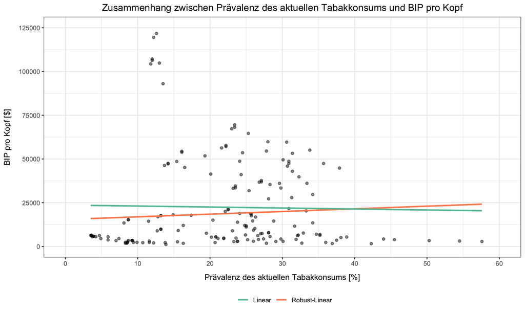

We observe a slight trend within the relationship while the direction of this relationship seems to be heavily influenced by the high GDP per capita and low tobacco prevalence outliers in the upper left hand area of the plot according to the different regression models used.  
As we are looking at the data without any consideration of time, let’s check whether those data points all belong to the same country and, if that is actually the case, what the relationship would look like without this one-country-bias.

#### 1.2. Scatter plot of interested variables; except outlier Qatar

```
## # A tibble: 7 × 5
##   `Country Name` `Country Code`  Year NY.GDP.PCAP.PP.KD SH.PRV.SMOK
##   <chr>          <chr>          <int>             <dbl>       <dbl>
## 1 Katar          QAT             2000            93050.        13.5
## 2 Katar          QAT             2005           104825.        13
## 3 Katar          QAT             2010           121765.        12.6
## 4 Katar          QAT             2015           119502.        12.2
## 5 Katar          QAT             2018           107185.        12
## 6 Katar          QAT             2019           106366.        12
## 7 Katar          QAT             2020           104322.        11.8
```

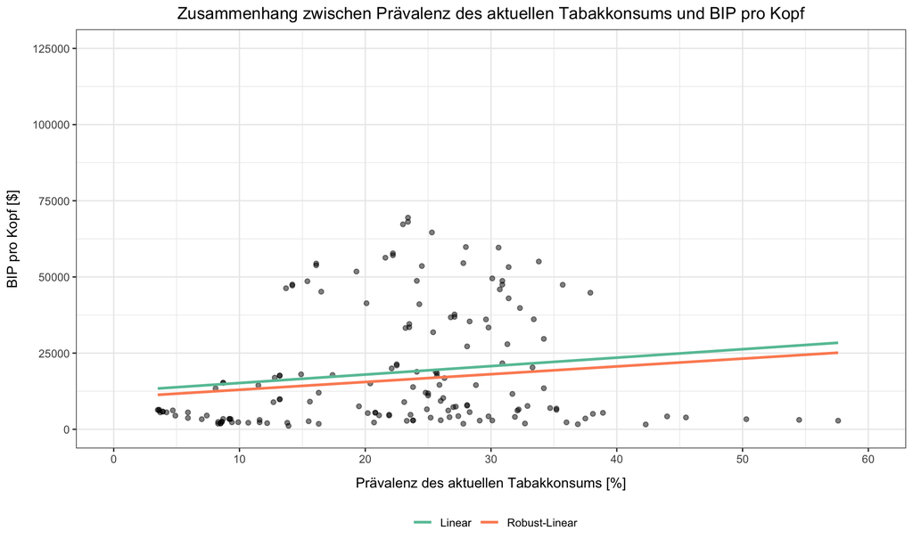

The removal of the Qatari data points leads us to slightly positive relationships for both, the linear as well as the robust-linear regression, visualized by the basically parallel straights divided only by marginal vertical differences.  
Keeping this influence of the outliers in mind, we want to do the small intermediate step to check whether the linear relationship is actually represented in each of the observable years and introduce another form of regression to get deeper understanding of how much the linear representation is appropriate.

#### 1.3. Scatter plot of interested variables with faceted years

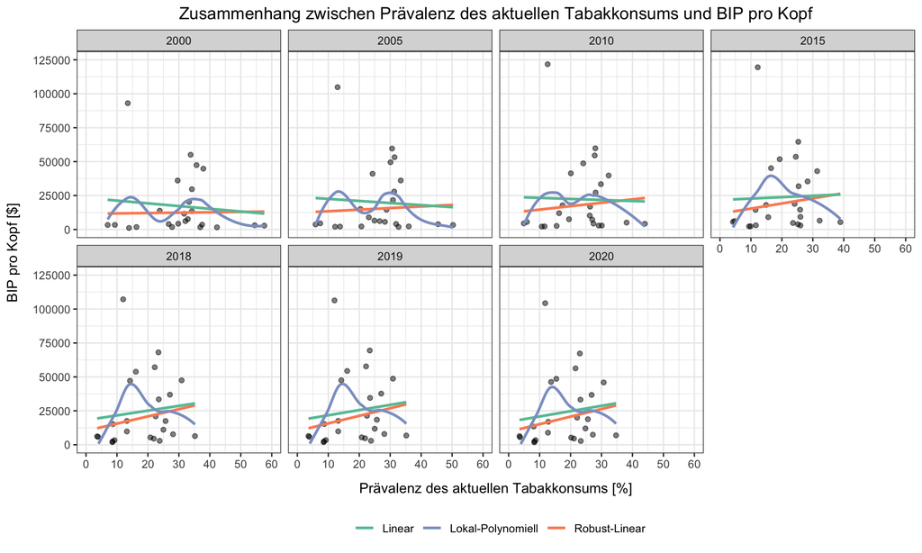

It seems that the Qatari data point in each of the years is still highly influential on the linear relationship. However, the relationship develops to more synchronized behaviour between the robust and non-robust relationship, with the non-robust changing from slightly negative to slightly positive.  
But looking at the distribution of the data points within each facet, something very interesting is happening. With the higher density of points in the horizontal middle of the cloud and the simultaneous deviation of some of those points in the higher GDP direction, we can recognize a presumably new relationship we want to visualize next.

#### 1.4. Scatter plot of interested variables with faceted years with density curves

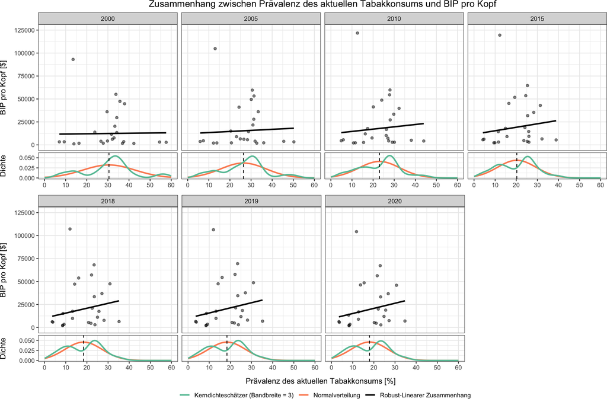

#### 1.5. Kullback-Leibler divergence for tobacco usage

This can be proven by calculating the Kullback-Leibler divergence for each of the years, comparing the KDE with the underlying normal distribution to check the accuracy of describing our empirical distribution by normal distribution.

| Jahr | KLD (Breite = 2) | KLD (Breite = 3) | KLD (Breite = 4) | KLD (Breite = 5) |
| --- | --- | --- | --- | --- |
| 2000 | 2.200456 | 1.3355127 | 0.7760908 | 0.4404161 |
| 2005 | 1.586584 | 0.8072496 | 0.4215260 | 0.2421420 |
| 2010 | 1.240258 | 0.5280582 | 0.2541619 | 0.1773269 |
| 2015 | 1.320069 | 0.5467187 | 0.2812418 | 0.2232322 |
| 2018 | 1.242548 | 0.5700443 | 0.3211268 | 0.2709994 |
| 2019 | 1.242548 | 0.5700443 | 0.3211268 | 0.2709994 |
| 2020 | 1.229573 | 0.5707539 | 0.3241600 | 0.2755441 |

### 2. Summary

In summary though, seeing the small values of KL divergence in general, the marginal differences in the last years, and the shift of the mean towards the low-percentage area, we can conclude that the prevalence of tobacco usage among adults nears a normally distributed data cloud. After a clear convergence in the early 2000s, the convergence stagnated slightly over the last years tending to a backwards development but not strong enough to make any assumptions for future developments. Still, with the general average consumption decreasing.